# Volcano plots with ggplot

Erik Larsen

7/16/2021

I developed the following code as a tutorial for graphical analysis of M. Bhattacharya Lab RNAseq data. The data was processed on [Usegalaxy.org](https://usegalaxy.org/) using a bioinformatics standard algorithm, known as [DESeq2](https://genomebiology.biomedcentral.com/articles/10.1186/s13059-014-0550-8). The plots are standard for differential gene expression analysis, but using the [ggplot2 R package](https://cran.r-project.org/package=ggplot2), employing advanced techniques. This `R Markdown` file is derived from the `Volcano script`.

## Environment Prep

Upload the packages that include `ggplot2`, which is a set of functions and commands that produce images, “Grammar of Graphics”, by mapping data to aesthetic properties

```r
  ## Install the tidyverse and reshape2 packages if not already done
    ## For example
#install.packages("tidyverse")
#install.packages("reshape2")

  # Load them from your R package library
## For data wrangling (slicing/adding/removing/melting/rearranging dataframes and their columns and rows):
library(tidyverse)
library(plyr)
library(dplyr)
library(reshape2)

library(ggplot2) ## For awesome, publication-quality graphs
library(ggrepel) ## For labeling mapped data on those plots
library(stats4)
library(readr) ## For importing data and files
```

Import the `Usegalaxy.org` data frame from the lab server that contains mean transcript counts of all the P60 WT and TMEM-GT/GT mice.

```r
aDRG_TPM = read_csv("C:/Users/Erik/Desktop/BoxCopy/Lab/Omics/RNAseq/Adult DRG/Processed Galaxy Output/Counts files to Upload/RNASeqRepResults.csv", col_names = c("GeneID", "WT", "Mut"))
```

Import the differential expression analysis data if not already done (`Import Dataset` in the `Environment Window`); it is directly called via the script below. These are the `DESeq2` results from `Usegalaxy.org`, computing a `Wald Test` on Salmon pseudoaligned counts files to determine which genes are differentially expressed.

- Before importing into `R`, **save the Galaxy DESeq2 Output** (dowloaded from Galaxy as a .txt file) **as a CSV** with headings to import into the `R Global Environment` to then manipulate for plotting purposes.
- Also add a column that converts `log2 FC` to `% WT` Expression in Excel if not already done (copy and paste the formula “`POWER(2,"_value_from_log2FC_cell")`” for the entire column. Save and import.
- Example data here is the same file as from the `Comprehensive RNAseq` script– the Adult (“aDRG”) dataset

```r
aDRG = read.csv("C:/Users/Erik/Desktop/BoxCopy/Lab/Omics/RNAseq/Adult DRG/Processed Galaxy Output/Test Results to Upload/DESeq2 Expression Results.csv")

  ## Filter (subset) genes that went undetected or were outliers in terms of counts;
  ## new dataframe should not contain any NAs in p-value columns
aDRG3 = subset(aDRG, (!is.na(aDRG[,"AdjP"])))

 ## Filter the DEGs by removing rRNAs and mitochondrial tRNAs.
aDRG9 = aDRG3 %>% filter(!grepl(aDRG3$GeneID, pattern = "Rps.+.?$|RP.+.?$|Rpl.+.?$|MRPL.+.?$|Mrpl.+.?$|MRPS.+.?$|Mrps.+.?$|.*Rik.+$|.*Rik$|Gm.+.?$|^[A-Z]+[A-Z].+.?$|^[0-9]+.+.?$"))
#mt.+.?$|  <-- string identifier for mitochondrial tRNAs

  ## Add a column to the DEG dataset that contains a string, describing whether the gene is differentially expressed
    ## First create the column and use Gene IDs as place-holders
aDRG9$labs = aDRG9$GeneID
  ## Replace DEGs with the string, "DEGs"
aDRG9$labs[which(aDRG9$AdjP <= 0.05)]= "DEGs"
  ## Replace the remaining genes with "Non-DEGs"
aDRG9$labs[which(aDRG9$AdjP >= 0.05)]= "Non-DEGs"

aDRG_DEG_list = c(aDRG9$GeneID[which(aDRG9$labs == "DEGs")])
```

## Data processing

How many genes are significantly different from WT expression?

```r
length(
  which(aDRG9$AdjP <= 0.10) ) ## For FDR <= 0.1
```

```
## [1] 535
```

```r
length(
  which(aDRG9$AdjP <= 0.05) ) ## For FDR <= 0.05
```

```
## [1] 376
```

```r
length(
  which(aDRG9$AdjP <= 0.01) ) ## For FDR <= 0.01
```

```
## [1] 205
```

Subset the dataframe to select differentially expressed genes with Adjusted P-values < 0.05 for use in pathway analysis tools (see Gene Ontology and Pathway Analysis R Markdown file or its source `GO Analysis` script) to find potential mechanistic pathways or other genes/interactions of interest.

```r
HITS.01 = subset(aDRG9, aDRG9$AdjP <= 0.01)
HITS.05 = subset(aDRG9, aDRG9$AdjP <= 0.05)
HITS.10 = subset(aDRG9, aDRG9$AdjP <= 0.10)

  ## Create a new data frame of the average reads from both genotypes of genes with an Adjusted P-value < 0.05
Candidate_Screen = aDRG_TPM %>%
  filter(GeneID %in% HITS.05$GeneID)
```

## Volcano plot prep

Volcano plots display the `fold change` of the manipulation relative to control (in this case log base 2 FC of mutant transcripts relative to wild type) along the x-axis, and `Adjusted P-values` along the y-axis

```r
aDRG9$log10ADJP = -log10(aDRG9$AdjP)
```

Create a new column that we will use to describe/slice all the data based on a feature (“`mapping`”). Totally arbitrary, but we’ll call them “genes of interest” or “`g.o.i.`” for short.

```r
  ## Make the new column a column of characters.
    ## Easiest way is to just use ' "" ' or another column already populated by strings (characters)
aDRG9$g.o.i. = aDRG9$GeneID

  ## Fill the points with appropriately indexed data;
    ## "D.E.G.s", aka "Differentially Expressed Genes",
    ## defined as being "genes of interest" with Adjusted P-Values of <= 0.05
aDRG9$g.o.i.[which(aDRG9$AdjP <= 0.05)] = "D.E.G.s"

aDRG9$g.o.i.[which(aDRG9$AdjP > 0.05)] = "Non-D.E.G.s"
```

Create labels on points we’re interested in labeling in the volcano plots.

```r
  ## Create the column, "labs"; hide all of the text labels with: ""
aDRG9$labs = ""
```

Label only these selected items; adjust for each experiment; for the current example and a more global volcano plot, highlight the most extreme data points on the plot.

```r
ix_label1 = which(aDRG9$log10ADJP > 50)

  ## Fill in the labels
aDRG9$labs[c(ix_label1)] = aDRG9$GeneID[c(ix_label1)]
```

## First volcano plot

Use the `aDRG9` dataframe as the data to plot Set the `x-axis` variable as log-base 2 fold change (`log2FC`) Set the `y-axis` as log-base 10 Adjusted P-value (`log10ADJP`) Set the points to be colored by the `g.o.i.` column previously created

Subset the data by each different group within that g.o.i. column

```r
  ## Find axis limits
min(aDRG9$log2.FC.)
```

```
## [1] -3.578847
```

```r
max(aDRG9$log2.FC.)
```

```
## [1] 1.455933
```

```r
max(aDRG9$log10ADJP)
```

```
## [1] 127.9469
```

Create the plot, and save it as a variable. Add layers:

- use the `ggplot` function to set the data
- specify the type of graph: scatter plot points; subset to the background/bottom layer; map the `x`, `y` variables/axes, set “`color`” = to the column we created, and set `alpha` (transparency) low for points that will be the bottom layer (get plotted over)
- repeat for the upper layer, using a stronger `alpha` (0 - 1)
- set the coordinates of the graph with `coord_cartesian`
- use `geom_hline` to create a horizontal line that will provide a clear division between DEGs and Non-DEGs
- use `geom_text` to add a label to the line
- use `labs` to add title, axes, and legend labels
- use `theme_bw` to turn the graph border and background white with a black outline
- use `theme` to control graph title and legend positions
- use `scale_color_manual` to map color to the appropriate data points

```r
vol1 = ggplot(data = aDRG9) +
  geom_point(data = subset(aDRG9, g.o.i. == "Non-D.E.G.s"),
             aes(x = log2.FC., y = log10ADJP, color = g.o.i.), alpha = 0.1) +
  geom_point(data = subset(aDRG9, g.o.i. == "D.E.G.s"),
             aes(x = log2.FC., y = log10ADJP, color = g.o.i.), alpha = 0.3) +
  coord_cartesian(xlim = c(min(aDRG$log2.FC.),
                           max(aDRG9$log2.FC.)),
                  ylim = c(0, max(aDRG9$log10ADJP))) +
  geom_hline(yintercept = min(aDRG9$log10ADJP[which(aDRG9$g.o.i. == "D.E.G.s")]),
             linetype = "dashed",
             color = "firebrick") +
  geom_text(x = -3, y = 4,
            label = "FDR \U2264 0.05",
            color = "firebrick", size = 3) +
  labs(title = expression(paste(italic("Tmem184b")^"GT/GT", " DRG mRNA Exp. Changes")),
       x = "log2 (FC) rel. to WT",
       y = "-log10 (Adj.P-val)",
       col = "Gene Data Type") +
  theme_bw() +
  theme(plot.title = element_text(hjust = 0.5), legend.position = c(0.90,0.87)) +
  scale_color_manual(values = c("darkgoldenrod4", "gray48"))
```

```r
  ## Overwrite the variable, adding labels
vol1 = vol1 + geom_text_repel(data = aDRG9,
                              x = aDRG9$log2.FC.,
                              y = aDRG9$log10ADJP,
                              color = "black",
                              aes(label = aDRG9$labs),
                              max.overlaps = Inf)
```

Plot the first volcano

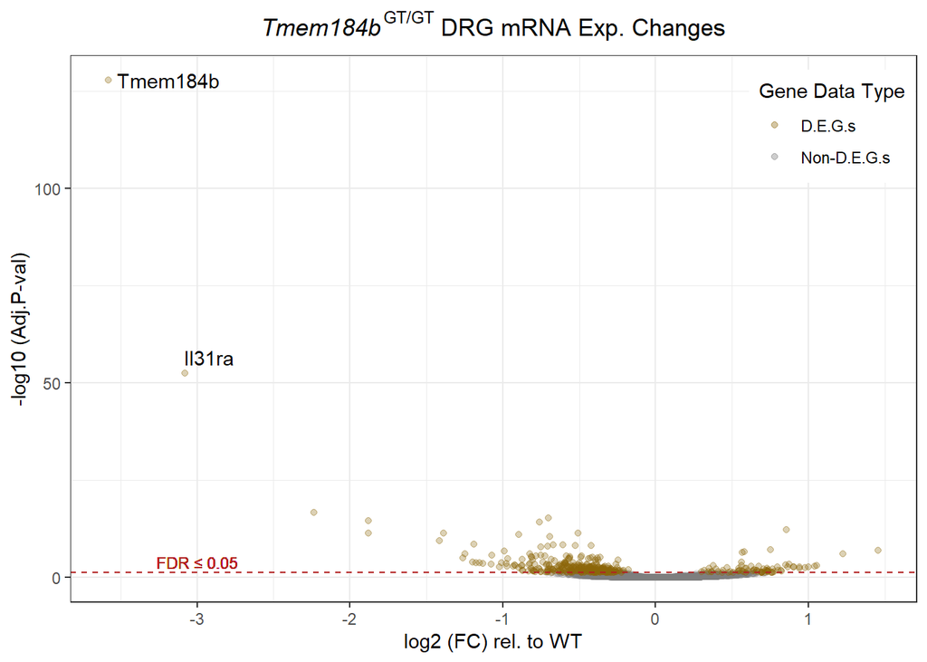

```r
  ## Plot the volcano
vol1
```

## Second volcano plot

Let’s add a little more rich data

```r
  ## Re-set the mapping columm
aDRG9$g.o.i. = ""

  ## Fill the points with appropriately indexed data:
    ## Notable pruriceptor genes defined as being "genes of interest", with ADJPs of <= 0.05
aDRG9$g.o.i.[
  c(2,5,8,9,13,14,20,30,33,44,51,69,75,95,112,122,136,192,230,248,327,328,329,331)]= "Itch-related D.E.G.s"

    ## Fill the DEGs not related to itch
aDRG9$g.o.i.[c(1:376)][
  -c(2,5,8,9,13,14,20,30,33,44,51,69,75,95,112,122,136,192,230,248,327,328,329,331)] = "D.E.G.s"

    ## Fill the rest (Non-DEGs)
aDRG9$g.o.i.[which(aDRG9$AdjP > 0.05)] = "Non-D.E.G.s"
```

Add new labels

```r
  ## Create a new "labs" column, though we could re-use the old one
aDRG9$labs2 = ""

aDRG9$labs2[c(2,5,8,9,13,20,30,51,112,331)] = aDRG9$GeneID[c(2,5,8,9,13,20,30,51,112,331)]
```

Store the new graph as a new variable + add a new subset + zoom in

```r
vol2 = ggplot(data = aDRG9) +
  geom_point(data = subset(aDRG9, g.o.i. == "Non-D.E.G.s"),
             aes(x = log2.FC., y = log10ADJP, color = g.o.i.), alpha = 0.1) +
  geom_point(data = subset(aDRG9, g.o.i. == "D.E.G.s"),
             aes(x = log2.FC., y = log10ADJP, color = g.o.i.), alpha = 0.3) +
  geom_point(data = subset(aDRG9, g.o.i. == "Itch-related D.E.G.s"),
             aes(x = log2.FC., y = log10ADJP, color = g.o.i.), alpha = 0.9) +
  coord_cartesian(xlim = c(-3.09,1.6), ylim = c(0,52)) +
  geom_hline(yintercept = min(aDRG9$log10ADJP[which(aDRG9$g.o.i. == "D.E.G.s")]),
             linetype = "dashed",
             color = "firebrick") +
  geom_text(x = -3, y = 2.5,
            label = "FDR \U2264 0.05",
            color = "firebrick", size = 3) +
  labs(title = expression(paste(italic("Tmem184b")^"GT/GT", " DRG mRNA Exp. Changes")),
       x = "log2 (FC) rel. to WT",
       y = "-log10 (Adj.P-val)",
       col = "Gene Data Type") +
  theme_bw() +
  theme(plot.title = element_text(hjust = 0.5),
        legend.position = c(0.85,0.85)) +
  scale_color_manual(values = c("darkgoldenrod4", "navy", "gray48"))
```

```r
  ## Overwrite the variable, adding labels
vol2 = vol2 + geom_text_repel(data = aDRG9,
                              x = aDRG9$log2.FC.,
                              y = aDRG9$log10ADJP,
                              color = "black",
                              aes(label = aDRG9$labs2),
                              max.overlaps = Inf)
```

Plot the second volcano

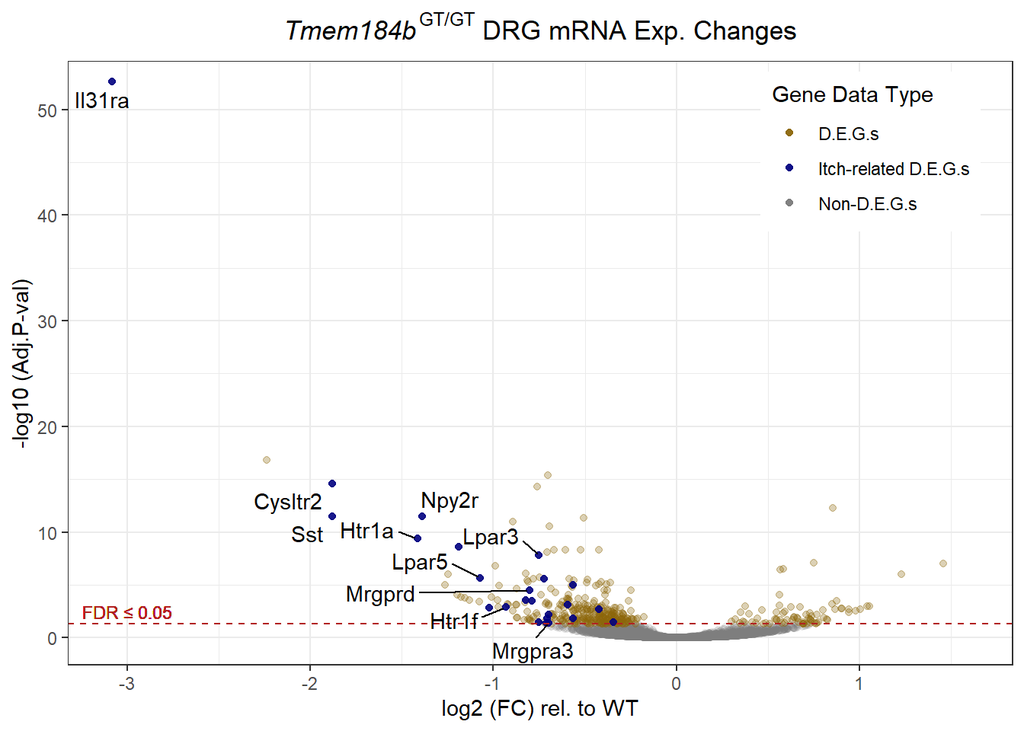

```r
  ## Plot the volcano
vol2
```